# Final Analysis Plant Origin Compounds on Fungal Morphogenesis

Ryan McCollum

2024-10-30

## Introduction

A designed experiment conducted by Miami University Microbiologist Marcia Lee looks to investigate the effects of different aloe based treatments on the prevention of fungal morphogenesis. This designed experiment was run on the fungus *Candida Albicans*, which is a part of normal microbial flora in mammals. However, when this fungus grows hyphae, it can attach in different ways and form and release buds that travel through the body that can start infection and disease. However, there is a possibility that using aloe, or aloe based compounds may be able to stop the formation of hypha and therefore reduce the potential for infection and disease from *Candida Albicans*. In this experiment, 7 different aloe based treatments are tested as well as 1 control group that receives no aloe based treatment. Each treatment was replicated 5 times, and in each replicate 200 cells were counted to see how many did not form anything, how many formed Pseudohyphae, Hyphae and Buds. In this experiment, Pseudohyphae are labeled as *PH*, Hyphae, or ‘Germ Tubes’ are labeled *GT*, and Buds are labeled *Buds*.

## Methods

The main hypotheses in question are as follows: **Hypothesis 1:** Exposure of Candida albicans cells to each of the seven treatments results in statistically significant reductions in formation of hyphae compared to non-exposed cells **Hypothesis 2:** Exposure of Candida albicans cells to A and A-SA treatments results in greater reductions in formation of germ tubes compared to treatments B and B-SA. **Hypothesis 3:** Exposure of Candida albicans cells to treatment Whole A results in the greatest reduction in germ tubes as compared to the other 6 treatments.

The hypotheses can each be tested through a series of contrasts that varies depending on the hypothesis and what result is of interest testing. However, 1 model based on the distribution of the proportions will be built that will be used in all contrast comparisons for each hypothesis. The contrasts for hypothesis 1, which compares each treatment to the control group, will be set up with null and alternative hypotheses as in equations *(1)* and *(2)*.

*(1) Null:* $p_{control} = p_{i}, i=1,...,7$ Where each $p_{i}$ represents a different treatment proportion and $p_{control}$ is the proportion of total cells that had some occurrence of hypha formation out of 200.

*(2) Alternative:* $p_{control} > p_{i}, i=1,...,7$

The Contrast for hypothesis 2 compares treatments with compound A to those with compound B. Since there are 2 of each, there are 4 different comparisons for hypothesis 2 (A to B, A to B-SA, A-SA to B, and A-SA to B-SA). These contrasts have null and alternative hypotheses in equations *(3)* and *(4)*.

*(3) Null:* $p_{compA} = p_{compB}; p_{compA} = p_{compB-SA};$ $p_{compA-SA} = p_{compB}; p_{compA-SA} = p_{compB-SA}$

*(4) Alternative:* $p_{compA} < p_{compB}; p_{compA} < p_{compB-SA};$ $p_{compA-SA} < p_{compB}; p_{compA-SA} < p_{compB-SA}$

Lastly, the contrast for hypothesis 3 investigates if the Whole A aloe treatment results in a greater reduction in hypa formation than any other treatment. Thus it has similar contrasts to hypothesis 1, with the Whole A compound acting as the control being compared against. The null and alternative hypothesis are in equations *(5)* and *(6)*.

*(5) Null:* $p_{WholeA} = p_{i}, i=1,...,6$ Where each $p_{i}$ represents a different treatment proportion for each of the 6 treatments that are not the control group or Whole A group, and $p_{WholeA}$ is the proportion of total cells that had some occurrence of hypha formation out of 200.

*(6) Alternative:* $p_{WholeA} < p_{i}, i=1,...,6$

### Model Building

When building a model, it must appropriately fit the data being modeled. Since the data is proportional, [0,1], a distribution needs to fit this interval. Initially it would seem that the data is continuous, however, each possible proportion is a frequency divided by 200, so the data is technically discrete. A beta distribution therefore is not ideal, as a beta distribution cannot have values of 0 and 1, but in the hypha growth proportion is is possible to obtain 0 hypha growing cells out of 200 or 200 out of 200 cells can have hypha. Therefore, some sort of counting distribution is the most appropriate. When choosing between a binomial or poisson distribution, there is not necessarily a better answer, but due to potential for better interpretability of results, this report will focus on the binomial-logistic model case. In the case of hypha growth, there appears to be zero-inflation. This means that when selecting the best model, a binomial-logistic model with a logit link function can be fit first, but it needs to be tested for over dispersion. This can be tested by looking at the sum or squared residual deviance of the binomial-logistic model of log odds divided by the residual degrees of freedom. This results in a Chi-squared test statistic that if close to 1, would suggest no overdispersion. If the data turns out to be over disperesed, then a quasi-binomial-logistic regression would be more appropriate and satisfy more model assumptions. A binomial-logistic model would have model form in equation *(7)*.

$$(7):
ln(\frac{P(\hat{p}=1)}{P(\hat{p}=0)}) =
\beta_0+\beta_{control}+\beta_{WholeA}+\beta_{A}+\beta_{A-SA}+\beta_{B}+\beta_{B-SA}+\beta_{A,B}+\beta_{A-SA,B-SA}$$
Where each beta is an indicator depending on which treatment is being represented. Therefore the log odds of hypha growth is predicted by the overall model intercept and a beta parameter depending on treatment. After fitting this model, it can be tested for over dispersion with $\phi = \frac{Deviance_{residual}}{DegreesFreedom_{residual}} > 1$ indicating over dispersion. If this is the case, the quasi-binomial logistic regression model will build a model similar to equation *(7)*, but with a dispersion parameter left to be estimated by the model. One thing to consider is that this models the log odds of the total hypha growth being 0 or 1, and normally a set cutoff point would be set with this type of modeling, say 50%, and everything above .5 would be rounded up to 1, and below rounded to 0 to predict a binary outcome of hypha growth. However, since this study is not focused on a binary outcome, the predictions from this model and coefficients can be interpreted without establishing a cutoff point, since there is no reason to round up or down to 1 and 0 for binary outcomes. One last important detail in using a binomial model is that it assumes the response variable is also binary. Therefore, the errors produced will be incorrect. To adjust for this, each proportion can be weighted by the number of trails done for that observation. Since each observation in this study is done by counting 200 cells, the number of trials for each observation is weighted the same at 200. One benefit of this modeling is that there are not a lot of assumptions, mainly just independence and linearity. Independence of observations is confirmed through the design of the experiment, and linearity of the log odds of total hypha formation to treatment type is checked by a Box-Tidwell test.

### Contrast Building

One last important thing to note is that all contrasts across hypotheses 1, 2 and 3 are being tested across the same data and with the same model. With an alpha level of 0.05, it may be more appropriate to test all contrasts at the same time. Therefore, the contrasts being used would be set up as seen in table 01. This way the type 1 error rate can be controlled across the entire experiment, giving more conservative estimates of odds ratios comparing groups for each hypothesis. Further, since a sidak contrast adjustment adjusts p-values assuming all treatment groups are independent, which we know they are based on experimental design, this will produce the most powerful, and reasonable, contrasts. #### Table 01: Contrasts

| Hypothesis | Contrast | Control | WholeA | CompA | CompA.SA | CompB | CompB.SA | ComboA_B | ComboA.SA_B.SA |
| --- | --- | --- | --- | --- | --- | --- | --- | --- | --- |
| 1 | 1 | 1 | -1 | 0 | 0 | 0 | 0 | 0 | 0 |
| 1 | 2 | 1 | 0 | -1 | 0 | 0 | 0 | 0 | 0 |
| 1 | 3 | 1 | 0 | 0 | -1 | 0 | 0 | 0 | 0 |
| 1 | 4 | 1 | 0 | 0 | 0 | -1 | 0 | 0 | 0 |
| 1 | 5 | 1 | 0 | 0 | 0 | 0 | -1 | 0 | 0 |
| 1 | 6 | 1 | 0 | 0 | 0 | 0 | 0 | -1 | 0 |
| 1 | 7 | 1 | 0 | 0 | 0 | 0 | 0 | 0 | -1 |
| 2 | 8 | 0 | 0 | 1 | 0 | -1 | 0 | 0 | 0 |
| 2 | 9 | 0 | 0 | 1 | 0 | 0 | -1 | 0 | 0 |
| 2 | 10 | 0 | 0 | 0 | 1 | -1 | 0 | 0 | 0 |
| 2 | 11 | 0 | 0 | 0 | 1 | 0 | -1 | 0 | 0 |
| 3 | 12 | 0 | 1 | -1 | 0 | 0 | 0 | 0 | 0 |
| 3 | 13 | 0 | 1 | 0 | -1 | 0 | 0 | 0 | 0 |
| 3 | 14 | 0 | 1 | 0 | 0 | -1 | 0 | 0 | 0 |
| 3 | 15 | 0 | 1 | 0 | 0 | 0 | -1 | 0 | 0 |
| 3 | 16 | 0 | 1 | 0 | 0 | 0 | 0 | -1 | 0 |
| 3 | 17 | 0 | 1 | 0 | 0 | 0 | 0 | 0 | -1 |

The results of each contrast comparison will be output in an odds ratio format. For example, the odds ration of the first contrast, Control vs Whole A, can be interpreted as:
$$\frac{\frac{P(HyphaInControl)}{P(NoHyphaInControl)}}{\frac{P(HyphaInWholeA)}{P(NoHyphaInWholeA)}}$$
This is a complicated formula, and the best way to interpret it is that if the odds ratio of a contrast is much larger than 1, then the odds that Hypha is found in the Control group in this situation is much larger than the odds that Hypha is found in the Whole A group, and vice-versa for a odds ratio lower than 1 (but above 0). The definition of odds is defined as the probability that an event will occur divided by the probability that it wont. So an odds ratio greater than 1 means that an event is more likely to occur than not, odds ratio less than 1 means an event is less likely to occur than not, and an odds ratio equal to 1 means an event is equally likely to occur than not to occur. In the context of this experiment, the ‘event’ of interest is a singular cell having some sort of hypha formation.

## Results

### Exploratory Data Analysis

The data is structured in a format that displays 1 replicate of a treatment in each row. There are 8 response variables that detail what kind of growth, if any, is seen on the cells. Each replicate examined 200 cells, so each row, or replicate has frequencies of each response type that add to 200 total. Manipulating this data by dividing each response by each replicate by 200 gives the proportion of cells that resulted in that response. Summary statistics for the average proportions of each response and treatment are reported in Table 02.

#### Table 02: Summary Statistics

| Treatment | Mean No Change in Morph | Variance No Change in Morph | Mean GT Only | Variance GT Only |
| --- | --- | --- | --- | --- |
| A-SA & B-SA | 0.741 | 0.0043175 | 0.085 | 0.0004625 |
| A & B | 0.814 | 0.0036550 | 0.089 | 0.0001175 |
| Comp A | 0.622 | 0.0041075 | 0.069 | 0.0006175 |
| Comp A-SA | 0.689 | 0.0026675 | 0.054 | 0.0004175 |
| Comp B | 0.691 | 0.0031925 | 0.122 | 0.0014575 |
| Comp B-SA | 0.614 | 0.0058425 | 0.221 | 0.0032050 |
| Control | 0.120 | 0.0012625 | 0.850 | 0.0011625 |
| Whole A | 0.927 | 0.0013075 | 0.030 | 0.0001375 |

| Treatment | Mean PH Only | Variance PH Only | Mean Buds Only | Variance Buds Only | Mean GT & PH | Variance GT & PH |
| --- | --- | --- | --- | --- | --- | --- |
| A-SA & B-SA | 0.150 | 0.0021750 | 0.005 | 0.0000500 | 0.004 | 1.75e-05 |
| A & B | 0.074 | 0.0035300 | 0.004 | 0.0000425 | 0.007 | 4.50e-05 |
| Comp A | 0.142 | 0.0003700 | 0.055 | 0.0004750 | 0.000 | 0.00e+00 |
| Comp A-SA | 0.138 | 0.0002700 | 0.028 | 0.0005575 | 0.002 | 2.00e-05 |
| Comp B | 0.067 | 0.0005075 | 0.053 | 0.0005200 | 0.004 | 3.00e-05 |
| Comp B-SA | 0.093 | 0.0024325 | 0.035 | 0.0001250 | 0.002 | 7.50e-06 |
| Control | 0.009 | 0.0000425 | 0.021 | 0.0002050 | 0.000 | 0.00e+00 |
| Whole A | 0.007 | 0.0000950 | 0.036 | 0.0010425 | 0.000 | 0.00e+00 |

| Treatment | Mean GT & Buds | Variance GT & Buds | Mean PH & Buds | Variance PH & Buds | Mean Multiple GT | Variance Multiple GT |
| --- | --- | --- | --- | --- | --- | --- |
| A-SA & B-SA | 0.005 | 0.0000250 | 0.007 | 0.0001200 | 0.003 | 0.0000200 |
| A & B | 0.007 | 0.0000200 | 0.001 | 0.0000050 | 0.004 | 0.0000175 |
| Comp A | 0.052 | 0.0004075 | 0.040 | 0.0001250 | 0.020 | 0.0000875 |
| Comp A-SA | 0.051 | 0.0004425 | 0.025 | 0.0001875 | 0.013 | 0.0001075 |
| Comp B | 0.031 | 0.0000925 | 0.015 | 0.0000875 | 0.017 | 0.0001450 |
| Comp B-SA | 0.015 | 0.0003000 | 0.009 | 0.0000425 | 0.011 | 0.0001800 |
| Control | 0.000 | 0.0000000 | 0.000 | 0.0000000 | 0.000 | 0.0000000 |
| Whole A | 0.000 | 0.0000000 | 0.000 | 0.0000000 | 0.000 | 0.0000000 |

To test these hypotheses, the density of the proportion of hyphae must be graphed to determine the best distribution or transformation to base hypothesis tests off of. To define hyphae growth, all response variables that include some form of hyphae growth are added to be 1 proportion that defines the number of cells out of 200 that experienced any of: Only GT growth, GT and PH growth, GT and Buds growth, or multiple GTs found. Table 02 displays the mean and variance of total hypha (GT) growth for each treatment when adding the 4 previously mentioned responses together

#### Table 02: Total Hypha Summary

| Treatment | Mean | Variance |
| --- | --- | --- |
| Control | 0.850 | 0.0011625 |
| Whole A | 0.030 | 0.0001375 |
| Comp A | 0.141 | 0.0024925 |
| Comp A-SA | 0.120 | 0.0005375 |
| Comp B | 0.174 | 0.0015800 |
| Comp B-SA | 0.249 | 0.0022175 |
| A & B | 0.107 | 0.0002700 |
| A-SA & B-SA | 0.097 | 0.0005200 |

Figure 01 plots the density of this variable, which is distributed from [0,1] since it is a proportion. It also appears to be bimodal, with most of the data being close to 0, and another concentration closer to 1. This means that the data is not normally distributed, and transforming it likely will not resolve this issue. There is also a concern of zero-inflation or overdispersion, since the data is technically count data, but a poisson distribution would also not initially fit well due to overdispersion.

#### Figure 01: Density of Hypha Formation Proportions

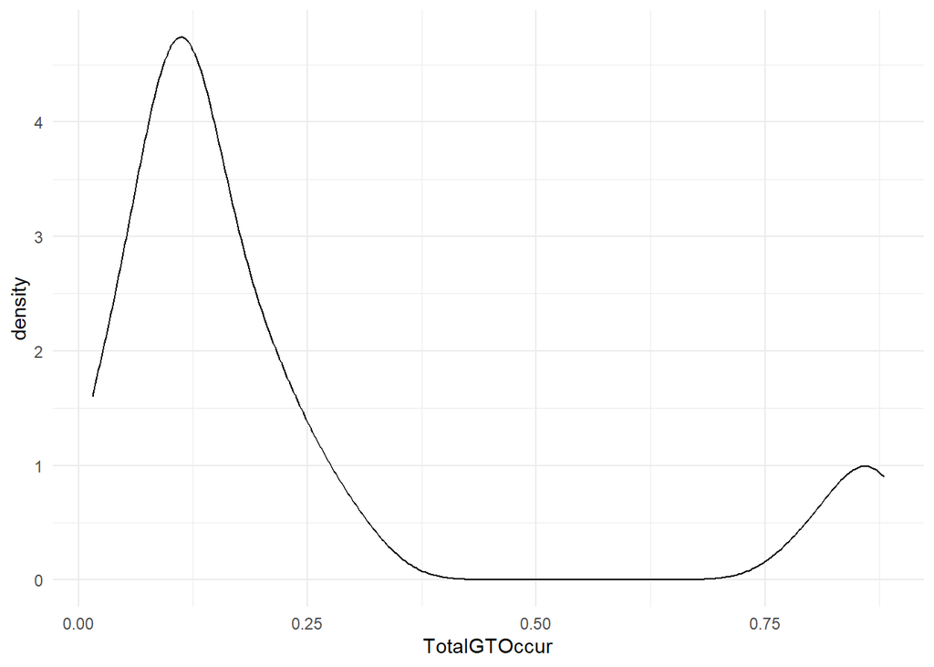

Figure 2 compares the 5 number summary of total hypha growth across treatment groups, keeping in mind that there is only 5 replicated per treatment. It appears that there is defnitiely a difference between the control group and treatment groups in terms of proportion of hypha growth out of 200, but detecting differences among treatment groups in the box-plot is harder. However, Whole A appears to be the best of all treatments, and hypothesis 3 will test to see which treatments it perfrosm statistically significantly better than, and the 2 compound A treatments appear to have a slightly better proportion than compound B.

#### Figure 02: Treatment Hypha Boxplot

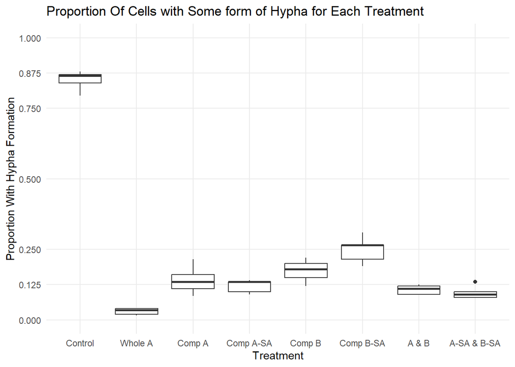

Figure 03 details the differences in 5 number summaries between treatment groups more clearly, once the control group is removed.

#### Figure 03: Treatment Hypha Boxplot without Control

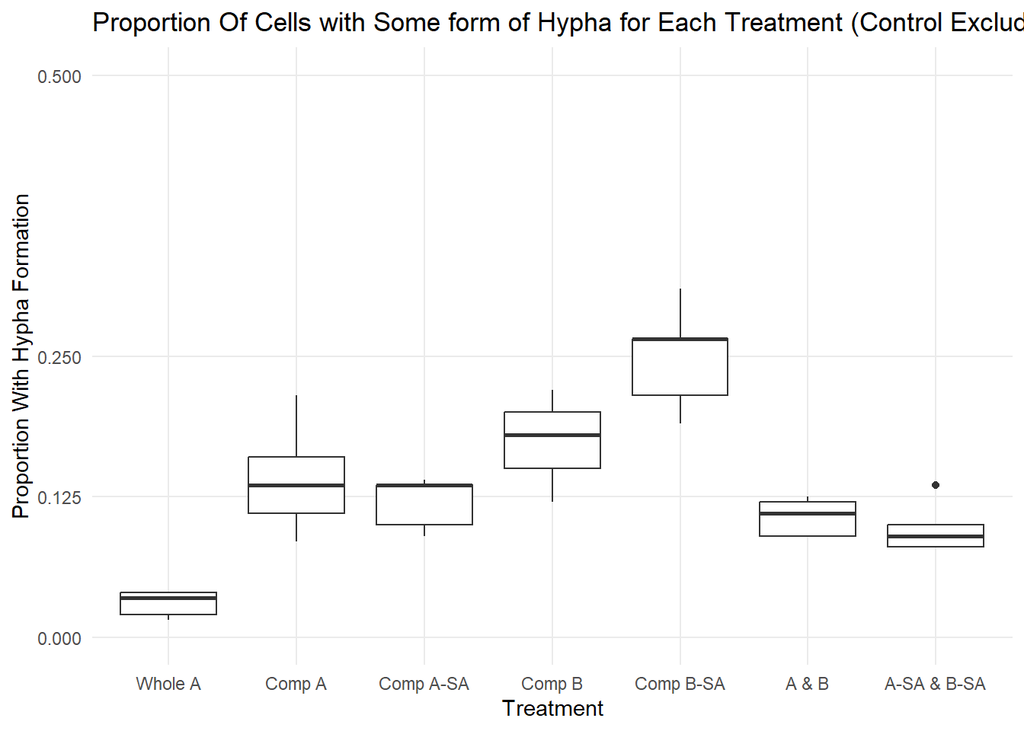

Figure 04 details where most of the hypha formation is coming from. It is apparent that of the total hypha proportion, no matter the treatment or control, the largest number of cells that have hypha growth have singular hypha growth only. Interestingly, the control and Whole A groups are the only groups that appear to have a total hypha proportion that is made entirely of singular hypha growth on cells. Based on knowledge from Professor Lee, singular hypha growth is the first stage of any abnormal hypha-related is a singular hypha. This means that all of the hypha-related growth in these groups, given more time, would have either resulted in a singular hypha, or potentially extra growth that was never seen in the time the experiment was conducted. Most other treatments seem to have hypha and buds as the 2nd most common formation with hypha, and hypha with pseudohyha appears to be the least common type of growth. It is also easy to see that in figure 4, the majority of non-treated cells saw hypha formations, but for all treatment groups the majority of cells saw no hypha formation, but this does not account for whether there was no excess formation, only pseudo hypha formations, only bud formations or a combination of pseudohypha and buds forming.

#### Figure 04: Detailing how each type of Hypha Formation Adds for each treatment

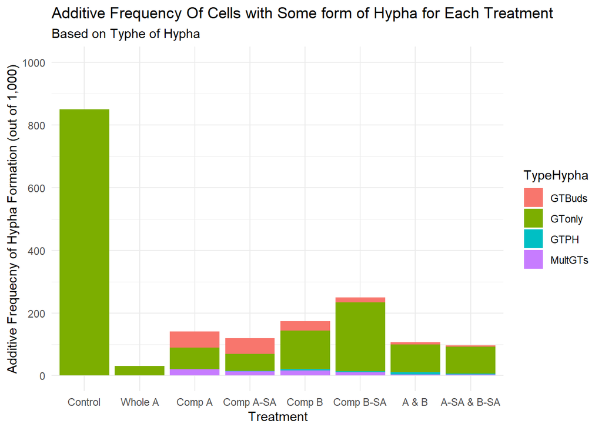

### Model Summary

After building a binomial logistic model, the over dispersion parameter is $\phi=1.78$, indicating over dispersion may be an issue with this model, and therefore a quasi-binomial version is more appropriate.

#### Table 03: Effects Of Log Odds of Hypha Proportion Per Treatment Effect

| Treatment | Effect | Standard Eror | df | Asymp Low CI | Asymp High CI |
| --- | --- | --- | --- | --- | --- |
| Control | 1.734601 | 0.1180941 | Inf | 1.503141 | 1.9660612 |
| Whole A | -3.476099 | 0.2471932 | Inf | -3.960588 | -2.9916090 |
| Comp A | -1.807009 | 0.1211650 | Inf | -2.044488 | -1.5695301 |
| Comp A-SA | -1.992430 | 0.1297631 | Inf | -2.246761 | -1.7380991 |
| Comp B | -1.557540 | 0.1112291 | Inf | -1.775545 | -1.3395344 |
| Comp B-SA | -1.103953 | 0.0975132 | Inf | -1.295075 | -0.9128303 |
| A & B | -2.121758 | 0.1364161 | Inf | -2.389128 | -1.8543871 |
| A-SA & B-SA | -2.231012 | 0.1424799 | Inf | -2.510267 | -1.9517562 |

Based on the results in Table 04, also graphed in Figure 05, it is easy to notice that there is a significant reduction in hypha formation when using an aloe based treatment compared to using the control group. All p-values are 0, suggesting a significant difference for all contrasts, and all odds ratios are very large, suggesting the odds of hypha formation in the control group is much higher than that in any of the treatment groups. In Figure 05, it is noticeable that none of the confidence bands of odds ratio estimates for each contrast come close to 1, which would signify equal odds.

#### Table 04: Contrasts for Hypothesis 1

| contrast | odds.ratio | SE | df | null | z.ratio | p.value |
| --- | --- | --- | --- | --- | --- | --- |
| Control vs Whole A | 183.22222 | 50.194423 | Inf | 1 | 19.02036 | 0 |
| Control vs Comp A | 34.52246 | 5.841049 | Inf | 1 | 20.93204 | 0 |
| Control vs Comp A-SA | 41.55556 | 7.291156 | Inf | 1 | 21.24202 | 0 |
| Control vs Comp B | 26.90038 | 4.364013 | Inf | 1 | 20.29321 | 0 |
| Control vs Comp B-SA | 17.09103 | 2.617498 | Inf | 1 | 18.53442 | 0 |
| Control vs A & B | 47.29283 | 8.533122 | Inf | 1 | 21.37297 | 0 |
| Control vs A-SA & B-SA | 52.75258 | 9.762323 | Inf | 1 | 21.42894 | 0 |

#### Figure 05: Odds Ratio Estimates For Hypothesis 1 Contrasts

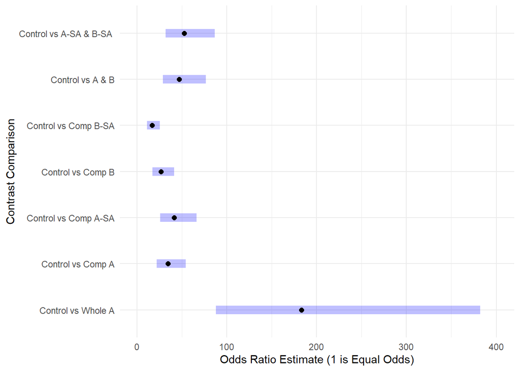

#### Table 05: Hypothesis 2 Contrasts

|  | contrast | odds.ratio | SE | df | null | z.ratio | p.value |
| --- | --- | --- | --- | --- | --- | --- | --- |
| 8 | Comp A vs Comp B | 0.7792140 | 0.1281632 | Inf | 1 | -1.516739 | 0.4253423 |
| 9 | Comp A vs Comp B-SA | 0.4950699 | 0.0769985 | Inf | 1 | -4.520372 | 0.0000247 |
| 10 | Comp A-SA vs Comp B | 0.6473354 | 0.1106364 | Inf | 1 | -2.544553 | 0.0430540 |
| 11 | Comp A-SA vs Comp B-SA | 0.4112815 | 0.0667586 | Inf | 1 | -5.473667 | 0.0000002 |

#### Figure 06: Odds Ratio Estimates For Hypothesis 2 Contrasts

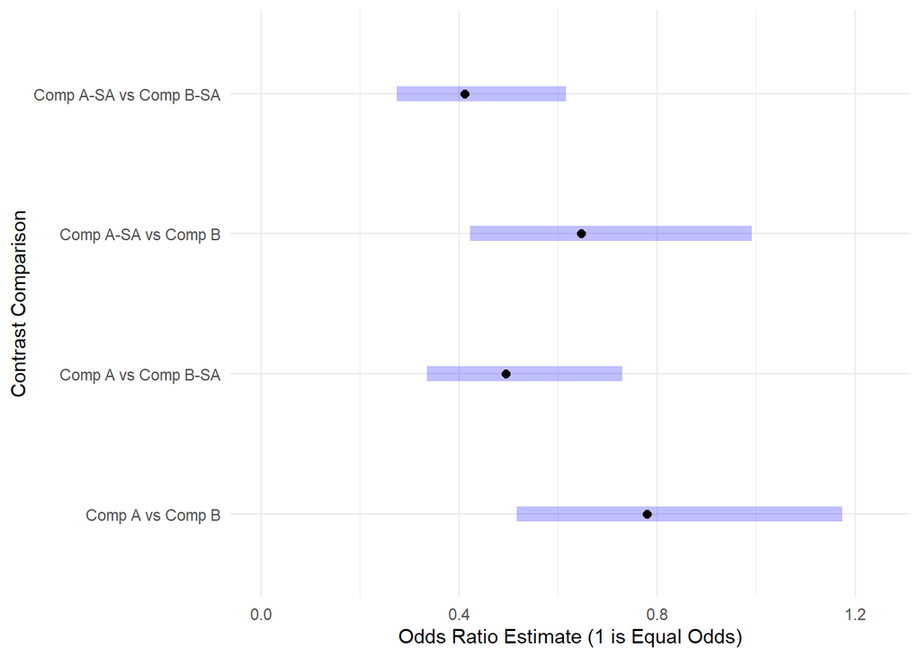

#### Table 06: Hypothesis 3 Contrasts

|  | contrast | odds.ratio | SE | df | null | z.ratio | p.value |
| --- | --- | --- | --- | --- | --- | --- | --- |
| 12 | Whole A vs Comp A | 0.1884185 | 0.0518700 | Inf | 1 | -6.062990 | 0.00e+00 |
| 13 | Whole A vs Comp A-SA | 0.2268041 | 0.0633198 | Inf | 1 | -5.314330 | 6.00e-07 |
| 14 | Whole A vs Comp B | 0.1468183 | 0.0397974 | Inf | 1 | -7.077849 | 0.00e+00 |
| 15 | Whole A vs Comp B-SA | 0.0932803 | 0.0247875 | Inf | 1 | -8.926848 | 0.00e+00 |
| 16 | Whole A vs A & B | 0.2581174 | 0.0728759 | Inf | 1 | -4.796906 | 9.70e-06 |
| 17 | Whole A vs A-SA & B-SA | 0.2879158 | 0.0821469 | Inf | 1 | -4.363895 | 7.67e-05 |

#### Figure 07: Odds Ratio Estimates For Hypothesis 3 Contrasts

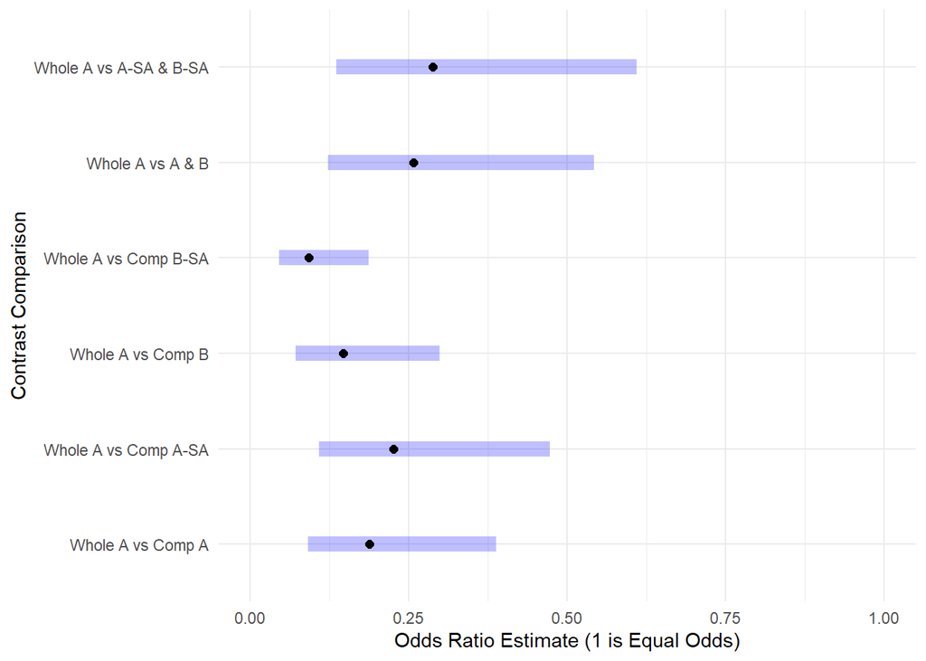

## References

Famoye, F., Eugene, N., & Lee, C. (2004, May 1). Beta-Normal Distribution: Bimodality Properties and Application. digitalcommons.wayne.edu. https://digitalcommons.wayne.edu/cgi/viewcontent.cgi?article=1554&context=jmasm#:~:text=The%20beta-normal%20distribution%20is%20characterized%20by%20four%20parameters,The%20beta-normal%20distribution%20can%20be%20unimodal%20or%20bimodal.

Love, K. (2023, September 19). Six common types of statistical contrasts. The Analysis Factor. https://www.theanalysisfactor.com/six-common-statistical-contrast/

Micheal Hughes (2024) Data Analytics Practicum

R Handbook: estimated marginal means for multiple comparisons. (n.d.). https://rcompanion.org/handbook/G_06.html

R: the Beta-Normal distribution. (n.d.). https://search.r-project.org/CRAN/refmans/VGAM/html/betanormUC.html

Search.r-project.org. (n.d.). https://search.r-project.org/

What are the (practical) differences between Tukey’s HSD and the Dunn-Sidak correction procedures? (n.d.). Cross Validated. https://stats.stackexchange.com/questions/350542/what-are-the-practical-differences-between-tukeys-hsd-and-the-dunn-sidak-corr